# Pitch Type Classification

Gustave Miller

2024-05-30

## Abstract

Within this project, I want to be able to understand if, taking different statistics from pitches can allow me to predict the type of pitch that was thrown. The algorithm I will using to go about this process is the k-Nearest Neighbors (kNN) algorithm. The data I am using for this will be pitch data from Los Angeles Dodgers pitcher, Clayton Kershaw, ranging from the 2020 season to the 2023 season. Each row of the data is 1 pitch from 1 game.

### Data variables

There are many different variables present in this data, the main ones and their meanings are as follows:

```r
# Using kable to create a table
kable(df, col.names = c("Variable", "Description"))
```

| Variable | Description |
| --- | --- |
| pitch_type | The type of pitch thrown (CH = Change Up, CU = Curveball, FF = 4-Seam-Fastball, FS = Split-Finger, SI = Sinker, SL = Slider), represented by abbreviations. |
| release_speed | The velocity of the pitch as it leaves the pitcher’s hand, usually measured in miles per hour (mph). |
| spin_rate | RPM (revolutions per minute) of the ball, indicating the rate of spin after the pitch is thrown. |
| type | Type of outcome of the pitch (Ball (B), Strike (S), Hit (X)). |
| balls | The count of balls prior to the pitch. |
| strikes | The count of strikes prior to the pitch. |
| plate_x | The horizontal location of the pitch as it crosses home plate, relative to the center of the plate. |
| plate_z | The vertical location of the pitch as it crosses home plate, relative to the ground. |
| outs_when_up | The number of outs recorded in the inning before the pitch is thrown. |
| delta_run_exp | The change in the expected number of runs as a result of the play. |
| ax | Acceleration of the ball in the x-plane (horizontal direction), usually measured in feet per second squared (ft/s^2). |
| az | Acceleration of the ball in the z-plane (vertical direction), usually measured in feet per second squared (ft/s^2). |

## Research Question

Based on all of this pitch data, using some of the data points can we correctly cluster pitches together using the velocity, spin rate, and acceleration of the pitch? If so, can we use this data to correctly predict what type of pitch was thrown without having it provided?

[Link to data](https://docs.google.com/spreadsheets/d/1wtuerUlOm_Pk2rytS5Z09F9ouin4eSInqZbYjKB9avU/edit?usp=sharing)

# 3. Analysis & Discussion

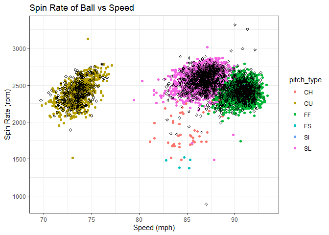

```r
# Plot the training data and the testing points by release speed and spin rate
# and acceleration in x versus z direction
ggplot(training_df, aes(x = release_speed, y = spin_rate, color = pitch_type)) +
  geom_point() +
  theme_bw() +
geom_point(data = testing_df, aes(x = release_speed, y = spin_rate),
           color = "black", pch = 5, size = 1) +
  labs(title = "Spin Rate of Ball vs Speed", x = "Speed (mph)",
       y = "Spin Rate (rpm)")
```

From Looking at this first plot on the left there are a couple of things we can notice early on. The Curveball as a pitch has a lower release speed and a relatively high spin rate. We can also point out that the Change-Up has a medium release speed and a lower spin rate. The Slider and the Fastball are similar in terms of spin rate however, the slider has a lower speed than the fastball. There are some pitches in here that are a little more difficult to observe. However from this we can see that there are different clusters formed based on the each pitch type and its spin rate and speed meaning that we can use speed and spin rate to classify the pitch type.

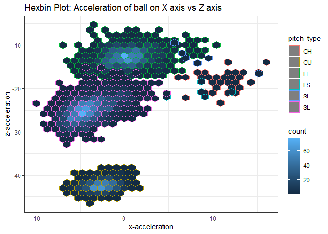

```r
ggplot(training_df, aes(x = ax, y = az, color = pitch_type)) +
  geom_hex() +
  theme_bw() +
  labs(title = "Hexbin Plot: Acceleration of ball on X axis vs Z axis",
       x = "x-acceleration",
       y = "z-acceleration")
```

This Hexbin plot demonstrates that there is a good clustering from the two variables x-acceleration(ax) and z-acceleration (az). This not only can be determined because of the clusters shown, but also that the centers are more concentrated and have a high count of pitches at the specific points. These variables az and ax is the acceleration of the ball as it approaches the plate. The ax is acceleration in the x direction which can be seen as higher on the curve, change up, and slider as these all have spin changing the direction of approach. The fastball, has very minimal change in the x direction and minimal in the z direction as it has only backspin and has a higher speed relative to the other pitches. The curve ball and slider have a higher z acceleration as they both have spin acting on them pushing them further down.

Thus using the classifiers speed, spin, x-acceleration, and z-acceleration can help to predict what pitches are thrown based on these values.

This is a summary table showing the mean, max, min and standard deviation values of the data used to predict the pitch type.

This table contributes to an understanding that a lot varies from pitch type. From the standard deviation of all the data we can see that there is a high deviation due to the differences in each pitches attributes.

```r
# Use kable to create a table
kable(summary_stats, col.names = c("Statistic", "Mean", "Max", "Min", "Std Dev"))
```

| Statistic | Mean | Max | Min | Std Dev |
| --- | --- | --- | --- | --- |
| Release Speed | 86.063627 | 93.400000 | 69.70000 | 5.947286 |
| Spin Rate | 2472.033581 | 3316.000000 | 889.00000 | 166.285222 |
| AZ | -23.067049 | -5.687601 | -46.56384 | 10.350441 |
| AX | -1.855703 | 16.123979 | -10.54891 | 3.243011 |

```r
set.seed(1234)
# Computing the knn algorithm to predict pitch type
Pitch_knn_classes <- knn(train = train_features,
                        test = test_features, cl = train_classes, k = 6)

# Showing the confusion matrix to see if the pitches were estimated correctly
CrossTable(x = Pitch_knn_classes, y = test_classes, prop.chisq = FALSE, prop.t = F, prop.r = F)
```

```
##
##
##    Cell Contents
## |-------------------------|
## |                       N |
## |           N / Col Total |
## |-------------------------|
##
##
## Total Observations in Table:  1697
##
##
##                   | test_classes
## Pitch_knn_classes |        CH |        CU |        FF |        SI |        SL | Row Total |
## ------------------|-----------|-----------|-----------|-----------|-----------|-----------|
##                CH |         6 |         1 |         1 |         0 |         0 |         8 |
##                   |     0.545 |     0.003 |     0.001 |     0.000 |     0.000 |           |
## ------------------|-----------|-----------|-----------|-----------|-----------|-----------|
##                CU |         2 |       288 |         0 |         0 |         0 |       290 |
##                   |     0.182 |     0.993 |     0.000 |     0.000 |     0.000 |           |
## ------------------|-----------|-----------|-----------|-----------|-----------|-----------|
##                FF |         3 |         0 |       670 |         6 |         5 |       684 |
##                   |     0.273 |     0.000 |     0.988 |     1.000 |     0.007 |           |
## ------------------|-----------|-----------|-----------|-----------|-----------|-----------|
##                FS |         0 |         0 |         0 |         0 |         1 |         1 |
##                   |     0.000 |     0.000 |     0.000 |     0.000 |     0.001 |           |
## ------------------|-----------|-----------|-----------|-----------|-----------|-----------|
##                SL |         0 |         1 |         7 |         0 |       706 |       714 |
##                   |     0.000 |     0.003 |     0.010 |     0.000 |     0.992 |           |
## ------------------|-----------|-----------|-----------|-----------|-----------|-----------|
##      Column Total |        11 |       290 |       678 |         6 |       712 |      1697 |
##                   |     0.006 |     0.171 |     0.400 |     0.004 |     0.420 |           |
## ------------------|-----------|-----------|-----------|-----------|-----------|-----------|
##
##
```

## Conclusion

Ultimately we can use speed, spin, and acceleration of the ball to correctly predict what type of pitch was thrown when given this data.

# 4. Citations

“Statcast Search.” Baseball Savant. Retrieved from link

# 5. Appendix: Data Details

For detailed explanations of the data fields in the CSV file, please visit the MLB Statcast website:

https://baseballsavant.mlb.com/csv-docs.

This resource provides thorough documentation of eeach of the dataset’s variables.